# FASTRESS 02 Analysis

# 1 Preparation

## 1.1 Data import

## 1.2 Import checks

# 2 Analysis sample setup

- `dat_main = fixed main sample from the cleaning script`
- `ids_complete = exactly those individuals from this main sample`
- `dat_main_final = the same dataset plus order_group`

## 2.1 **Main sample**

Create fixed analysis samples

| n_rows | n_sessions | n_conditions | n |
| --- | --- | --- | --- |
| 2 | 2 | 2 | 30 |

## 2.2 **Sample overview**

| n_total_sessions | n_total_persons |
| --- | --- |
| 75 | 43 |

| n_sessions | n_persons |
| --- | --- |
| 60 | 30 |

| n_complete_persons |
| --- |
| 30 |

| planned_condition | n_sessions | n_persons |
| --- | --- | --- |
| satiated | 30 | 30 |
| fasted | 30 | 30 |

# 3 Order and carryover

## 3.1 Inspect session order structure

Check whether the order of the conditions is relevant:

- whether participants were fasting or satiated first
- whether order has a main effect
- whether order moderates the effect of planned_condition

## 3.2 Crossover check

| n | nn |
| --- | --- |
| 2 | 30 |

| session | planned_condition | n |
| --- | --- | --- |
| T1 | satiated | 14 |
| T1 | fasted | 16 |
| T2 | satiated | 16 |
| T2 | fasted | 14 |

## 3.3 Order variable

| order_group | n |
| --- | --- |
| satiated_first | 14 |
| fasted_first | 16 |

## 3.4 Merge order

Merge order variable into the main sample

| n_sessions | n_conditions | n |
| --- | --- | --- |
| 2 | 2 | 30 |

| n_rows | n_ids | n_missing_order |
| --- | --- | --- |
| 60 | 30 | 0 |

| order_group | session | planned_condition | n |
| --- | --- | --- | --- |
| satiated_first | T1 | satiated | 14 |
| satiated_first | T2 | fasted | 14 |
| fasted_first | T1 | fasted | 16 |
| fasted_first | T2 | satiated | 16 |

- `satiated_first`: T1 = satiated, T2 = fasted
- `fasted_first`: T1 = fasted, T2 = satiated

=> merge correctly

## 3.5 Order descriptives

| order_group | planned_condition | n_obs | n_ids | total_kcal_M | total_kcal_SD |
| --- | --- | --- | --- | --- | --- |
| satiated_first | satiated | 14 | 14 | 270.4729 | 140.8589 |
| satiated_first | fasted | 14 | 14 | 354.9821 | 173.9883 |
| fasted_first | satiated | 16 | 16 | 369.2569 | 162.7327 |
| fasted_first | fasted | 16 | 16 | 369.1381 | 172.7027 |

## 3.6 Order models

Test three models:  
A) a baseline model without order;  
B) plus the main effect of order;  
C) plus the interaction between planned_condition and order_group.

-> If C does not perform better than B, there is no evidence that the condition effect depends on the order.

### 3.6.1 Baseline vs. additive order model

```
Data: dat_main_order
Models:
m_base: total_kcal ~ planned_condition + (1 | subject)
m_order_add: total_kcal ~ planned_condition + order_group + (1 | subject)
            npar    AIC    BIC  logLik -2*log(L)  Chisq Df Pr(>Chisq)
m_base         4 772.18 780.56 -382.09    764.18
m_order_add    5 773.06 783.53 -381.53    763.06 1.1237  1     0.2891
```

**Interpretation**

### 3.6.2 Additive order model vs. interaction model

```
Data: dat_main_order
Models:
m_order_add: total_kcal ~ planned_condition + order_group + (1 | subject)
m_order_int: total_kcal ~ planned_condition * order_group + (1 | subject)
            npar    AIC    BIC  logLik -2*log(L)  Chisq Df Pr(>Chisq)
m_order_add    5 773.06 783.53 -381.53    763.06
m_order_int    6 771.99 784.55 -379.99    759.99 3.0671  1    0.07989 .
---
Signif. codes:  0 '***' 0.001 '**' 0.01 '*' 0.05 '.' 0.1 ' ' 1
```

### 3.6.3 Final order model estimates

```
Linear mixed model fit by maximum likelihood . t-tests use Satterthwaite's
  method [lmerModLmerTest]
Formula: total_kcal ~ planned_condition * order_group + (1 | subject)
   Data: dat_main_order

      AIC       BIC    logLik -2*log(L)  df.resid
    772.0     784.6    -380.0     760.0        54

Scaled residuals:
    Min      1Q  Median      3Q     Max
-1.7400 -0.6235  0.1195  0.5039  1.6738

Random effects:
 Groups   Name        Variance Std.Dev.
 subject  (Intercept) 16655    129.06
 Residual              8280     90.99
Number of obs: 60, groups:  subject, 30

Fixed effects:
                                                Estimate Std. Error     df
(Intercept)                                       270.47      42.20  41.49
planned_conditionfasted                            84.51      34.39  30.00
order_groupfasted_first                            98.78      57.79  41.49
planned_conditionfasted:order_groupfasted_first   -84.63      47.09  30.00
                                                t value    Pr(>|t|)
(Intercept)                                       6.409 0.000000108 ***
planned_conditionfasted                           2.457      0.0200 *
order_groupfasted_first                           1.709      0.0948 .
planned_conditionfasted:order_groupfasted_first  -1.797      0.0824 .
---
Signif. codes:  0 '***' 0.001 '**' 0.01 '*' 0.05 '.' 0.1 ' ' 1

Correlation of Fixed Effects:
            (Intr) plnnd_ ordr__
plnnd_cndtn -0.407
ordr_grpfs_ -0.730  0.298
plnnd_cn:__  0.298 -0.730 -0.407
```

```
                                                     2.5 %    97.5 %
.sig01                                                  NA        NA
.sigma                                                  NA        NA
(Intercept)                                      187.75718 353.18853
planned_conditionfasted                           17.10210 151.91648
order_groupfasted_first                          -14.47908 212.04712
planned_conditionfasted:order_groupfasted_first -176.92913   7.67306
```

| effect | term | estimate | std.error | statistic | df | p.value | conf.low | conf.high |
| --- | --- | --- | --- | --- | --- | --- | --- | --- |
| fixed | (Intercept) | 270.473 | 42.203 | 6.409 | 41.489 | 0.000 | 185.273 | 355.672 |
| fixed | planned_conditionfasted | 84.509 | 34.392 | 2.457 | 30.000 | 0.020 | 14.271 | 154.747 |
| fixed | order_groupfasted_first | 98.784 | 57.788 | 1.709 | 41.489 | 0.095 | -17.880 | 215.448 |
| fixed | planned_conditionfasted:order_groupfasted_first | -84.628 | 47.093 | -1.797 | 30.000 | 0.082 | -180.805 | 11.549 |

**Interpretation**

# 4 Sample

## 4.1 Demographics

Demographic characteristics of the final analysis sample

| **Characteristic** | **N = 30**<sup>1</sup> |
| --- | --- |
| age | 20.87 (2.30), [18.00, 29.00] |
| sex_male_m_female_f |  |
| f | 22 (73%) |
| m | 8 (27%) |
| education_label |  |
| Maturitaet oder Berufsmaturitaet | 26 (87%) |
| obligatorische Schule abgeschlossen | 1 (3.3%) |
| Universitaet Fachhochschule PH ETH | 3 (10%) |

<sup>1</sup> Mean (SD), [Min, Max]; n (%)

# 5 Assumptions

# 6 Manipulation checks

## 6.1 Stress ratings

```
# A tibble: 1 × 3
  n_obs n_ids n_session_labels
  <int> <int>            <int>
1    75    43                2
```

| session | n |
| --- | --- |
| T1 | 43 |
| T2 | 32 |

| n_obs | n_ids | baseline_M | baseline_SD | mild_M | mild_SD | strong_M | strong_SD | dMB_M | dMB_SD | dSB_M | dSB_SD | dSM_M | dSM_SD | peak_M | peak_SD |
| --- | --- | --- | --- | --- | --- | --- | --- | --- | --- | --- | --- | --- | --- | --- | --- |
| 75 | 43 | 3.84254 | 1.774676 | 2.524444 | 1.564118 | 5.017778 | 1.855431 | -1.318095 | 1.4761 | 1.175238 | 1.169183 | 2.493333 | 1.629412 | 5.084444 | 1.796797 |

### 6.1.1 Stress paired test summary

| Comparison | N pairs | Shapiro p | Reported test | Statistic | df | p | Cohen's d | Magnitude |
| --- | --- | --- | --- | --- | --- | --- | --- | --- |
| Stress mild - baseline | 75 | 0.145 | paired t-test | t = -7.73 | 74 | < .001 | -0.89 | large |
| Stress strong - baseline | 75 | 0.047 | wilcoxon signed-rank test | V = 2687.5 |  | < .001 | 1.01 | large |
| Stress strong - mild | 75 | 0.009 | wilcoxon signed-rank test | V = 2699 |  | < .001 | 1.53 | large |

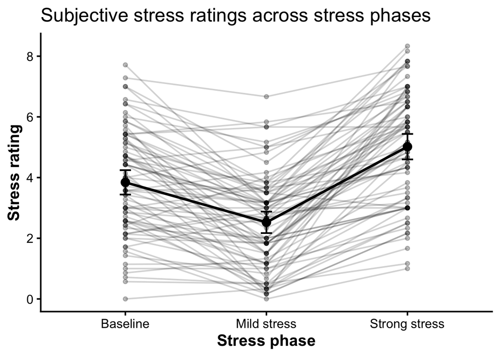

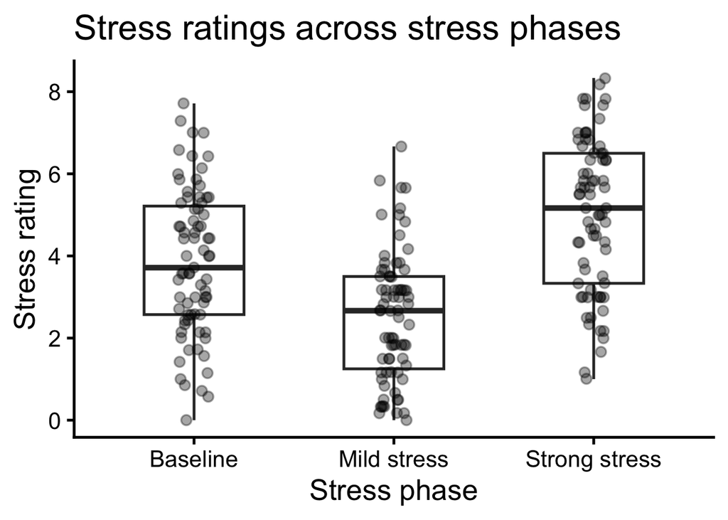

## 6.2 Blood markers

| n_persons | n_ketones_paired | n_glucose_paired |
| --- | --- | --- |
| 43 | 42 | 43 |

### 6.2.1 Blood marker paired test summary

| Comparison | N pairs | Shapiro p | Reported test | Statistic | df | p | Cohen's d | Magnitude |
| --- | --- | --- | --- | --- | --- | --- | --- | --- |
| Ketones fasted - satiated | 29 | 0.376 | paired t-test | t = 4 | 28 | < .001 | 0.74 | moderate |
| Glucose fasted - satiated | 30 | 0.946 | paired t-test | t = -5.09 | 29 | < .001 | -0.93 | large |

## 6.3 Hunger ratings

| n_persons | n_hunger_paired |
| --- | --- |
| 43 | 30 |

| fasted_M | fasted_SD | satiated_M | satiated_SD |
| --- | --- | --- | --- |
| 7.361111 | 2.652791 | 2.567568 | 2.489317 |

### 6.3.1 Hunger paired test summary

| Comparison | N pairs | Shapiro p | Reported test | Statistic | df | p | Cohen's d | Magnitude |
| --- | --- | --- | --- | --- | --- | --- | --- | --- |
| Hunger fasted - satiated | 30 | 0.026 | wilcoxon signed-rank test | V = 402 |  | < .001 | 1.63 | large |

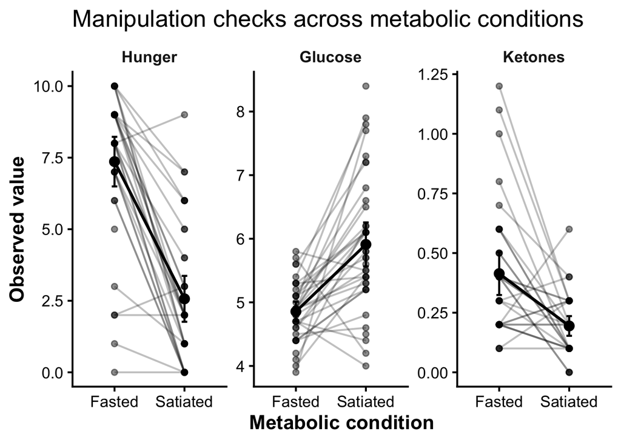

# 7 Subjective stress reactivity (during MRI)

### 7.0.1 Association with questionnaire-based SRS

| r_srs_mri |
| --- |
| 0.2891379 |

## 7.1 Standardized variables for beta coefficients

# 8 Moderator samples

## 8.1 Moderator-specific datasets

## 8.2 Moderator N’s

Document sample sizes for moderator analyses

| sample | n_rows | n_ids |
| --- | --- | --- |
| dat_main_final | 60 | 30 |
| dat_main_srs | 60 | 30 |
| dat_main_mri | 60 | 30 |
| dat_main_sses | 60 | 30 |
| dat_main_cerq_adaptive | 60 | 30 |
| dat_main_cerq_maladaptive | 60 | 30 |
| dat_main_stadit | 60 | 30 |
| dat_main_edeq | 60 | 30 |

## 8.3 Sample flow overview

| sample | n_rows | n_ids |
| --- | --- | --- |
| analysis_session | 75 | 43 |
| ids_complete | 30 | 30 |
| dat_main | 60 | 30 |
| dat_main_final | 60 | 30 |
| dat_main_srs | 60 | 30 |
| dat_main_mri | 60 | 30 |
| dat_main_sses | 60 | 30 |
| dat_main_cerq_adaptive | 60 | 30 |
| dat_main_cerq_maladaptive | 60 | 30 |
| dat_main_stadit | 60 | 30 |
| dat_main_edeq | 60 | 30 |

# 9 Preliminary outcome checks

## 9.1 Distributions

| p_zero_total_kcal | p_zero_high_kcal | p_zero_low_kcal | p_zero_prop_high_kcal |
| --- | --- | --- | --- |
| 0 | 0 | 0 | 0 |

| total_kcal_n | total_kcal_min | total_kcal_p25 | total_kcal_p50 | total_kcal_p75 | total_kcal_p95 | total_kcal_max | high_kcal_n | high_kcal_min | high_kcal_p25 | high_kcal_p50 | high_kcal_p75 | high_kcal_p95 | high_kcal_max | low_kcal_n | low_kcal_min | low_kcal_p25 | low_kcal_p50 | low_kcal_p75 | low_kcal_p95 | low_kcal_max | prop_high_kcal_n | prop_high_kcal_min | prop_high_kcal_p25 | prop_high_kcal_p50 | prop_high_kcal_p75 | prop_high_kcal_p95 | prop_high_kcal_max |
| --- | --- | --- | --- | --- | --- | --- | --- | --- | --- | --- | --- | --- | --- | --- | --- | --- | --- | --- | --- | --- | --- | --- | --- | --- | --- | --- | --- |
| 60 | 85.24 | 196.745 | 341.53 | 479.0525 | 609.428 | 682.75 | 60 | 55.28 | 124.945 | 187.04 | 306.085 | 414.567 | 506.02 | 60 | 29.96 | 61.1925 | 110.76 | 159.6875 | 259.3135 | 327.65 | 60 | 0.3610949 | 0.5682414 | 0.6382901 | 0.7134801 | 0.8133229 | 0.8904896 |

| fastress_id | session | planned_condition | total_kcal | high_kcal | low_kcal | prop_high_kcal |
| --- | --- | --- | --- | --- | --- | --- |
| sub-004 | T2 | satiated | 682.75 | 506.02 | 176.73 | 0.7411498 |
| sub-001 | T1 | fasted | 665.23 | 387.32 | 277.91 | 0.5822347 |
| sub-004 | T1 | fasted | 615.28 | 455.70 | 159.58 | 0.7406384 |
| sub-019 | T2 | fasted | 609.12 | 454.60 | 154.52 | 0.7463226 |
| sub-007 | T2 | fasted | 581.46 | 402.32 | 179.14 | 0.6919135 |
| sub-015 | T2 | fasted | 578.36 | 319.68 | 258.68 | 0.5527353 |
| sub-008 | T1 | fasted | 572.29 | 244.64 | 327.65 | 0.4274756 |
| sub-051 | T2 | satiated | 549.93 | 278.58 | 271.35 | 0.5065736 |
| sub-015 | T1 | satiated | 547.83 | 304.90 | 242.93 | 0.5565595 |
| sub-008 | T2 | satiated | 546.10 | 389.52 | 156.58 | 0.7132760 |

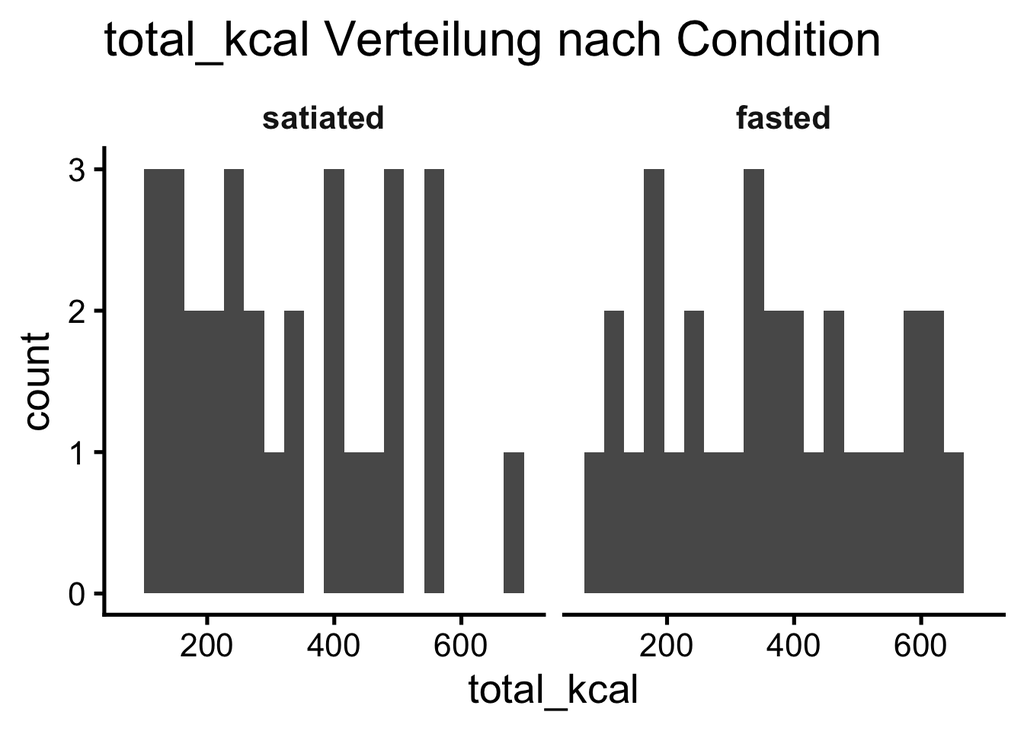

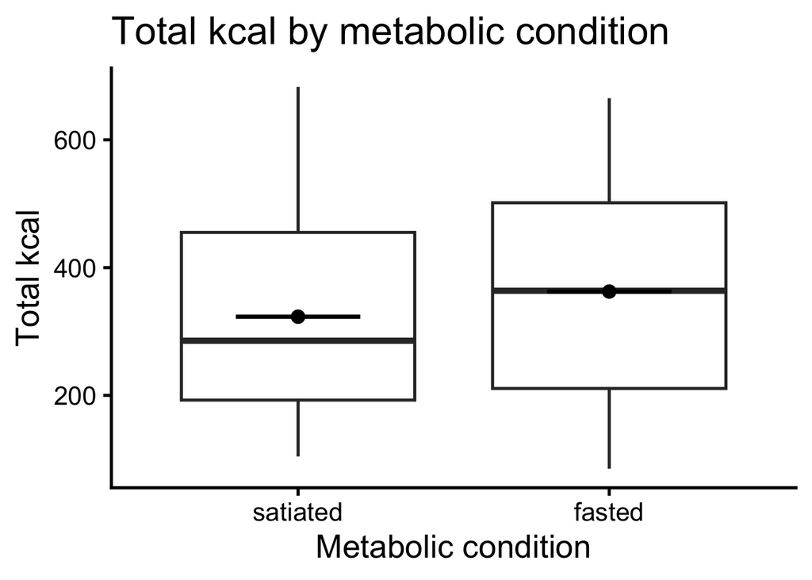

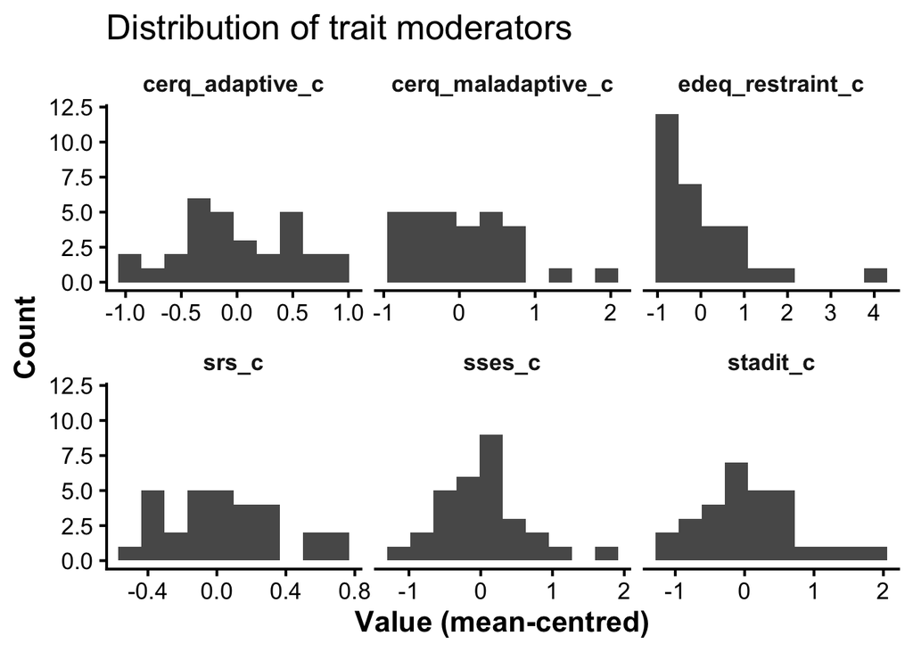

## 9.2 Descriptives

| planned_condition | n_obs | n_ids | total_kcal_M | total_kcal_SD | high_kcal_M | high_kcal_SD | low_kcal_M | low_kcal_SD | prop_high_M | prop_high_SD |
| --- | --- | --- | --- | --- | --- | --- | --- | --- | --- | --- |
| satiated | 39 | 37 | 367.7641 | 186.4826 | 234.6379 | 131.7253 | 133.1262 | 73.06250 | 0.6286997 | 0.1204367 |
| fasted | 36 | 36 | 357.2181 | 166.6060 | 222.0156 | 115.6321 | 135.2025 | 80.04602 | 0.6267595 | 0.1157412 |

| planned_condition | n_obs | n_ids | total_kcal_M | total_kcal_SD |
| --- | --- | --- | --- | --- |
| satiated | 30 | 30 | 323.1577 | 158.4436 |
| fasted | 30 | 30 | 362.5320 | 170.4380 |

| planned_condition | high_kcal_M | high_kcal_SD | low_kcal_M | low_kcal_SD | prop_M | prop_SD |
| --- | --- | --- | --- | --- | --- | --- |
| satiated | 207.7007 | 116.8769 | 115.4570 | 65.67631 | 0.6339134 | 0.1266131 |
| fasted | 224.6673 | 116.9054 | 137.8647 | 82.34811 | 0.6265926 | 0.1178779 |

# 10 Model specification

## 10.1 Random effects

First, use a random intercept as the main model

Then test the random slope

- Only include the random slope if the model is stable
- no major warnings appear
- and the fit is visibly better

=> A random-intercept model was retained as the primary specification, as adding a random slope for planned_condition was not considered sufficiently justified given the small sample and two observations per subject.

## 10.2 Model helpers

Define reporting functions for mixed models

# 11 Main analyses

## 11.1 Condition effects

### 11.1.1 Summary across all outcomes

| Outcome | b (fasted) | SE | 95% CI | χ² | df | p |
| --- | --- | --- | --- | --- | --- | --- |
| Total kcal | 39.37 | 24.73 | [-9.09, 87.84] | 2.43 | 1 | 0.119 |
| High-kcal foods | 16.97 | 17.75 | [-17.82, 51.75] | 0.90 | 1 | 0.343 |
| Low-kcal foods | 22.41 | 12.90 | [-2.87, 47.69] | 2.88 | 1 | 0.090 |
| Proportion high-kcal | -0.01 | 0.03 | [-0.06, 0.04] | 0.08 | 1 | 0.778 |

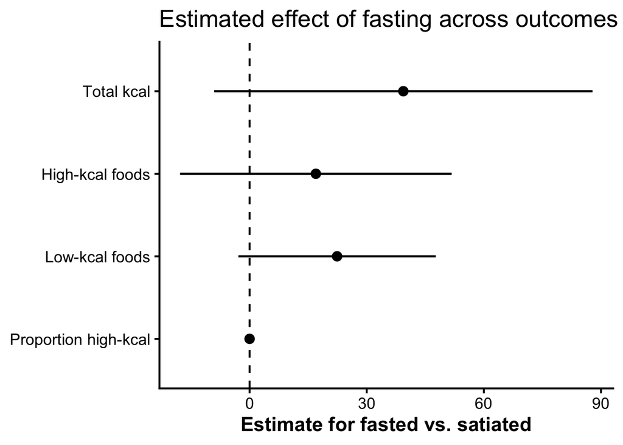

## 11.2 Session Effects

### 11.2.1 Fixed effects including session

| Effect | Estimate | CI | p |
| --- | --- | --- | --- |
| Fasted vs. satiated | 42.20 | [-3.96, 88.35] | 0.083 |
| T2 vs. T1 | 42.31 | [-3.84, 88.46] | 0.082 |

### 11.2.2 Model comparison for adding session

| Comparison | Chisq | df | p |
| --- | --- | --- | --- |
| Adding session | 3.07 | 1 | 0.080 |

# 12 Moderation analyses

## 12.1 Moderation helper functions

### 12.1.1 Moderation 1: SRS

m_srs_add = main effect of Condition plus main effect of Moderator

m_srs_int = plus interaction; ANOVA tests whether the interaction provides additional explanatory power

#### 12.1.1.1 Sample check

| n_rows | n_ids | n_nonmiss_outcome | n_nonmiss_cond | n_nonmiss_mod | n_complete_for_model |
| --- | --- | --- | --- | --- | --- |
| 60 | 30 | 60 | 60 | 60 | 60 |

#### 12.1.1.2 Model comparison

| npar | AIC | BIC | logLik | -2*log(L) | Chisq | Df | Pr(>Chisq) |
| --- | --- | --- | --- | --- | --- | --- | --- |
| 5 | 773.2163 | 783.6880 | -381.6082 | 763.2163 |  |  |  |
| 6 | 775.1965 | 787.7625 | -381.5982 | 763.1965 | 0.01984533 | 1 | 0.8879699 |

m_srs_add -> The interaction model does not fit significantly better than the additive model.

#### 12.1.1.3 Interaction model estimates

| effect | term | estimate | std.error | statistic | df | p.value | conf.low | conf.high |
| --- | --- | --- | --- | --- | --- | --- | --- | --- |
| fixed | (Intercept) | 325.751 | 29.313 | 11.113 | 42.548 | 0.000 | 266.616 | 384.885 |
| fixed | planned_conditionfasted | 39.745 | 24.858 | 1.599 | 30.000 | 0.120 | -11.022 | 90.511 |
| fixed | srs_c | -74.419 | 89.027 | -0.836 | 42.548 | 0.408 | -254.014 | 105.177 |
| fixed | planned_conditionfasted:srs_c | -10.637 | 75.495 | -0.141 | 30.000 | 0.889 | -164.819 | 143.545 |

## 12.2 Additional Analysis: MRI subjective stress reactivity

| n_rows | n_ids | n_nonmiss_outcome | n_nonmiss_cond | n_nonmiss_mod | n_complete_for_model |
| --- | --- | --- | --- | --- | --- |
| 60 | 30 | 60 | 60 | 60 | 60 |

| npar | AIC | BIC | logLik | -2*log(L) | Chisq | Df | Pr(>Chisq) |
| --- | --- | --- | --- | --- | --- | --- | --- |
| 5 | 773.0630 | 783.5348 | -381.5315 | 763.0630 |  |  |  |
| 6 | 773.4297 | 785.9958 | -380.7149 | 761.4297 | 1.633297 | 1 | 0.2012477 |

| effect | term | estimate | std.error | statistic | df | p.value | conf.low | conf.high |
| --- | --- | --- | --- | --- | --- | --- | --- | --- |
| fixed | (Intercept) | 316.670 | 29.268 | 10.820 | 42.003 | 0.000 | 257.606 | 375.735 |
| fixed | planned_conditionfasted | 44.006 | 24.327 | 1.809 | 30.000 | 0.080 | -5.675 | 93.688 |
| fixed | mri_reactivity_c | -33.330 | 22.100 | -1.508 | 42.003 | 0.139 | -77.930 | 11.269 |
| fixed | planned_conditionfasted:mri_reactivity_c | 23.799 | 18.369 | 1.296 | 30.000 | 0.205 | -13.716 | 61.313 |

### 12.2.1 Moderation 2: CERQ

#### 12.2.1.1 Adaptive CERQ

| n_rows | n_ids | n_nonmiss_outcome | n_nonmiss_cond | n_nonmiss_mod | n_complete_for_model |
| --- | --- | --- | --- | --- | --- |
| 60 | 30 | 60 | 60 | 60 | 60 |

#### 12.2.1.2 Model comparison

| npar | AIC | BIC | logLik | -2*log(L) | Chisq | Df | Pr(>Chisq) |
| --- | --- | --- | --- | --- | --- | --- | --- |
| 5 | 774.0654 | 784.5371 | -382.0327 | 764.0654 |  |  |  |
| 6 | 774.0207 | 786.5868 | -381.0104 | 762.0207 | 2.044648 | 1 | 0.1527423 |

m_cerq_adapt_add -> There is no evidence that adaptive CERQ moderates the condition effect.

#### 12.2.1.3 Interaction model estimates

| effect | term | estimate | std.error | statistic | df | p.value | conf.low | conf.high |
| --- | --- | --- | --- | --- | --- | --- | --- | --- |
| fixed | (Intercept) | 322.471 | 29.330 | 10.994 | 41.494 | 0.000 | 263.259 | 381.684 |
| fixed | planned_conditionfasted | 40.278 | 23.906 | 1.685 | 30.000 | 0.102 | -8.545 | 89.101 |
| fixed | cerq_adaptive_c | 52.568 | 58.374 | 0.901 | 41.494 | 0.373 | -65.278 | 170.414 |
| fixed | planned_conditionfasted:cerq_adaptive_c | -69.209 | 47.579 | -1.455 | 30.000 | 0.156 | -166.377 | 27.959 |

#### 12.2.1.4 Maladaptive CERQ

| n_rows | n_ids | n_nonmiss_outcome | n_nonmiss_cond | n_nonmiss_mod | n_complete_for_model |
| --- | --- | --- | --- | --- | --- |
| 60 | 30 | 60 | 60 | 60 | 60 |

#### 12.2.1.5 Model comparison

| npar | AIC | BIC | logLik | -2*log(L) | Chisq | Df | Pr(>Chisq) |
| --- | --- | --- | --- | --- | --- | --- | --- |
| 5 | 770.8008 | 781.2726 | -380.4004 | 760.8008 |  |  |  |
| 6 | 772.1847 | 784.7507 | -380.0923 | 760.1847 | 0.6161898 | 1 | 0.4324667 |

#### 12.2.1.6 Interaction model estimates

| effect | term | estimate | std.error | statistic | df | p.value | conf.low | conf.high |
| --- | --- | --- | --- | --- | --- | --- | --- | --- |
| fixed | (Intercept) | 325.969 | 28.231 | 11.546 | 43.254 | 0.000 | 269.045 | 382.893 |
| fixed | planned_conditionfasted | 40.792 | 24.540 | 1.662 | 30.000 | 0.107 | -9.325 | 90.909 |
| fixed | cerq_maladaptive_c | -58.462 | 42.986 | -1.360 | 43.254 | 0.181 | -145.136 | 28.213 |
| fixed | planned_conditionfasted:cerq_maladaptive_c | -29.482 | 37.365 | -0.789 | 30.000 | 0.436 | -105.791 | 46.827 |

H3a was not supported: there was no evidence that adaptive cognitive emotion regulation moderated the association between metabolic condition and total caloric intake. -> direction was even positive

H3b was not supported: maladaptive cognitive emotion regulation was not significantly associated with greater caloric intake, and no significant interaction with metabolic condition was observed. -> direction was even negative

### 12.2.2 Moderation 3: STADI Trait Anxiety

#### 12.2.2.1 Total caloric intake

| n_rows | n_ids | n_nonmiss_outcome | n_nonmiss_cond | n_nonmiss_mod | n_complete_for_model |
| --- | --- | --- | --- | --- | --- |
| 60 | 30 | 60 | 60 | 60 | 60 |

#### 12.2.2.2 Model comparison

| npar | AIC | BIC | logLik | -2*log(L) | Chisq | Df | Pr(>Chisq) |
| --- | --- | --- | --- | --- | --- | --- | --- |
| 5 | 773.8909 | 784.3626 | -381.9455 | 763.8909 |  |  |  |
| 6 | 775.8753 | 788.4413 | -381.9376 | 763.8753 | 0.01566474 | 1 | 0.9003978 |

m_stadit_add -> The interaction model does not fit significantly better than the additive model. = There is no evidence that trait anxiety moderates the effect of metabolic condition on total_kcal.

#### 12.2.2.3 Interaction model estimates

| effect | term | estimate | std.error | statistic | df | p.value | conf.low | conf.high |
| --- | --- | --- | --- | --- | --- | --- | --- | --- |
| fixed | (Intercept) | 324.476 | 29.521 | 10.991 | 42.295 | 0.000 | 264.913 | 384.039 |
| fixed | planned_conditionfasted | 39.118 | 24.805 | 1.577 | 30.000 | 0.125 | -11.540 | 89.776 |
| fixed | stadit_c | -22.478 | 41.580 | -0.541 | 42.295 | 0.592 | -106.372 | 61.417 |
| fixed | planned_conditionfasted:stadit_c | 4.373 | 34.938 | 0.125 | 30.000 | 0.901 | -66.979 | 75.725 |

#### 12.2.2.4 High-calorie intake

#### 12.2.2.5 Model comparison

| npar | AIC | BIC | logLik | -2*log(L) | Chisq | Df | Pr(>Chisq) |
| --- | --- | --- | --- | --- | --- | --- | --- |
| 5 | 733.2991 | 743.7708 | -361.6495 | 723.2991 |  |  |  |
| 6 | 735.2743 | 747.8404 | -361.6372 | 723.2743 | 0.02476315 | 1 | 0.8749587 |

#### 12.2.2.6 Interaction model estimates

| effect | term | estimate | std.error | statistic | df | p.value | conf.low | conf.high |
| --- | --- | --- | --- | --- | --- | --- | --- | --- |
| fixed | (Intercept) | 208.494 | 20.957 | 9.949 | 42.597 | 0.000 | 166.219 | 250.770 |
| fixed | planned_conditionfasted | 17.198 | 17.803 | 0.966 | 30.000 | 0.342 | -19.160 | 53.556 |
| fixed | stadit_c | -13.530 | 29.518 | -0.458 | 42.597 | 0.649 | -73.075 | 46.015 |
| fixed | planned_conditionfasted:stadit_c | -3.947 | 25.075 | -0.157 | 30.000 | 0.876 | -55.157 | 47.264 |

**H4a was not supported:** trait anxiety was not significantly associated with total caloric intake or high-calorie intake.

**H4b was not supported:** there was no evidence that trait anxiety moderated the effect of metabolic condition on either total caloric intake or high-calorie intake.

### 12.2.3 Moderation 4: EDEQ & SSES

### 12.2.4 EDE-Q restraint

| n_rows | n_ids | n_nonmiss_outcome | n_nonmiss_cond | n_nonmiss_mod | n_complete_for_model |
| --- | --- | --- | --- | --- | --- |
| 60 | 30 | 60 | 60 | 60 | 60 |

#### 12.2.4.1 Model comparison

| npar | AIC | BIC | logLik | -2*log(L) | Chisq | Df | Pr(>Chisq) |
| --- | --- | --- | --- | --- | --- | --- | --- |
| 5 | 774.1778 | 784.6495 | -382.0889 | 764.1778 |  |  |  |
| 6 | 776.1749 | 788.7410 | -382.0875 | 764.1749 | 0.002846492 | 1 | 0.957451 |

#### 12.2.4.2 Interaction model estimates

| effect | term | estimate | std.error | statistic | df | p.value | conf.low | conf.high |
| --- | --- | --- | --- | --- | --- | --- | --- | --- |
| fixed | (Intercept) | 323.169 | 29.598 | 10.919 | 42.193 | 0.000 | 263.447 | 382.891 |
| fixed | planned_conditionfasted | 39.459 | 24.776 | 1.593 | 30.000 | 0.122 | -11.140 | 90.058 |
| fixed | edeq_restraint_c | -0.166 | 28.373 | -0.006 | 42.193 | 0.995 | -57.418 | 57.085 |
| fixed | planned_conditionfasted:edeq_restraint_c | -1.267 | 23.751 | -0.053 | 30.000 | 0.958 | -49.773 | 47.239 |

### 12.2.5 SSES

| n_rows | n_ids | n_nonmiss_outcome | n_nonmiss_cond | n_nonmiss_mod | n_complete_for_model |
| --- | --- | --- | --- | --- | --- |
| 60 | 30 | 60 | 60 | 60 | 60 |

#### 12.2.5.1 Model comparison

| npar | AIC | BIC | logLik | -2*log(L) | Chisq | Df | Pr(>Chisq) |
| --- | --- | --- | --- | --- | --- | --- | --- |
| 5 | 774.0102 | 784.4819 | -382.0051 | 764.0102 |  |  |  |
| 6 | 775.5358 | 788.1019 | -381.7679 | 763.5358 | 0.4743687 | 1 | 0.4909842 |

#### 12.2.5.2 Interaction model estimates

| effect | term | estimate | std.error | statistic | df | p.value | conf.low | conf.high |
| --- | --- | --- | --- | --- | --- | --- | --- | --- |
| fixed | (Intercept) | 323.123 | 29.431 | 10.979 | 42.081 | 0.000 | 263.731 | 382.514 |
| fixed | planned_conditionfasted | 39.139 | 24.534 | 1.595 | 30.000 | 0.121 | -10.967 | 89.244 |
| fixed | sses_c | 4.372 | 51.139 | 0.085 | 42.081 | 0.932 | -98.825 | 107.569 |
| fixed | planned_conditionfasted:sses_c | 29.477 | 42.630 | 0.691 | 30.000 | 0.495 | -57.584 | 116.539 |

H5 was also not supported for stress eating tendencies: SSES showed neither a significant main effect on total caloric intake nor a significant interaction with metabolic condition.

## 12.3 Overview all Moderations

| Moderator | b | β | 95% CI | p |
| --- | --- | --- | --- | --- |
| Stress reactivity (SRS) | -10.64 | -0.02 | [-158.61, 137.33] | 0.889 |
| Stress reactivity (MRI-task) | 23.80 | 0.19 | [-12.20, 59.80] | 0.205 |
| Adaptive ER (CERQ) | -69.21 | -0.21 | [-162.46, 24.04] | 0.156 |
| Maladaptive ER (CERQ) | -29.48 | -0.12 | [-102.72, 43.75] | 0.436 |
| Trait anxiety (STADI) | 4.37 | 0.02 | [-64.10, 72.85] | 0.901 |
| Restrained eating (EDE-Q) | -1.27 | -0.01 | [-47.82, 45.28] | 0.958 |
| Stress-induced eating (SSES) | 29.48 | 0.10 | [-54.08, 113.03] | 0.495 |

## 12.4 Store models

## 12.5 Moderation summary

This table summarises whether the interaction model improved model fit over the additive model for each moderator.

| moderator | p_int |
| --- | --- |
| srs | 0.888 |
| mri | 0.201 |
| sses | 0.491 |
| cerq_adapt | 0.153 |
| cerq_mal | 0.432 |
| stadit | 0.900 |
| edeq | 0.957 |

# 13 Sensitivity analyses

## 13.1 Mismatch check

```
# A tibble: 1 × 3
  n_rows n_ids n_missing_order
   <int> <int>           <int>
1     60    30               0
```

```
# A tibble: 1 × 4
  n_rows n_sessions n_conditions     n
   <int>      <int>        <int> <int>
1      2          2            2    29
```

```
Mit allen Sessions:
```

```
                         Estimate Std. Error       df   t value
(Intercept)             323.15767   29.53766 42.19397 10.940532
planned_conditionfasted  39.37433   24.72644 30.00000  1.592398
                                      Pr(>|t|)
(Intercept)             0.00000000000006744623
planned_conditionfasted 0.12177882204270683297
```

```
Ohne mismatch Sessions:
```

```
                         Estimate Std. Error       df   t value
(Intercept)             319.62207   30.43962 40.76596 10.500198
planned_conditionfasted  41.79345   25.46046 29.00000  1.641504
                                     Pr(>|t|)
(Intercept)             0.0000000000003683058
planned_conditionfasted 0.1114952626036193883
```

```
                             2.5 %    97.5 %
.sig01                          NA        NA
.sigma                          NA        NA
(Intercept)             259.961507 379.28263
planned_conditionfasted  -8.108145  91.69504
```

Excluding sessions with metabolic mismatches did not materially change the main result.

## 13.2 Log transform

```
Data: dat
Models:
m0: f_m0
m1: f_m1
   npar    AIC    BIC  logLik -2*log(L) Chisq Df Pr(>Chisq)
m0    3 88.283 94.566 -41.142    82.283
m1    4 88.681 97.059 -40.341    80.681 1.602  1     0.2056
```

```
                        Estimate Std. Error       df   t value
(Intercept)             5.654250  0.0979531 43.13881 57.724053
planned_conditionfasted 0.108792  0.0848087 30.00000  1.282792
                                                                  Pr(>|t|)
(Intercept)             0.000000000000000000000000000000000000000001755722
planned_conditionfasted 0.209387614836791968730977941959281452000141143799
```

```
                              2.5 %   97.5 %
.sig01                           NA       NA
.sigma                           NA       NA
(Intercept)              5.46226523 5.846234
planned_conditionfasted -0.05743005 0.275014
```

The null effect remained unchanged when total caloric intake was log-transformed, indicating that the main finding was not driven by skewness of the outcome distribution.

## 13.3 Outlier check

### 13.3.1 Sample trimming rule

Extreme observations were defined as sessions above the 99th percentile of total caloric intake.

### 13.3.2 Primary model including all observations

| Estimate | Std. Error | df | t value | Pr(>\|t\|) |
| --- | --- | --- | --- | --- |
| 323.15767 | 29.53766 | 42.19397 | 10.940532 | 0.00000000000006744623 |
| 39.37433 | 24.72644 | 30.00000 | 1.592398 | 0.12177882204270683297 |

[output not shown]

### 13.3.3 Primary model after excluding extreme observations

| Estimate | Std. Error | df | t value | Pr(>\|t\|) |
| --- | --- | --- | --- | --- |
| 316.15016 | 28.95031 | 43.52627 | 10.920441 | 0.00000000000004754225 |
| 46.38184 | 25.36338 | 28.80453 | 1.828693 | 0.07781808943389778577 |

# 14 Plots and diagnostics

## 14.1 Plots

### 14.1.1 Main outcome plot (total_kcal)

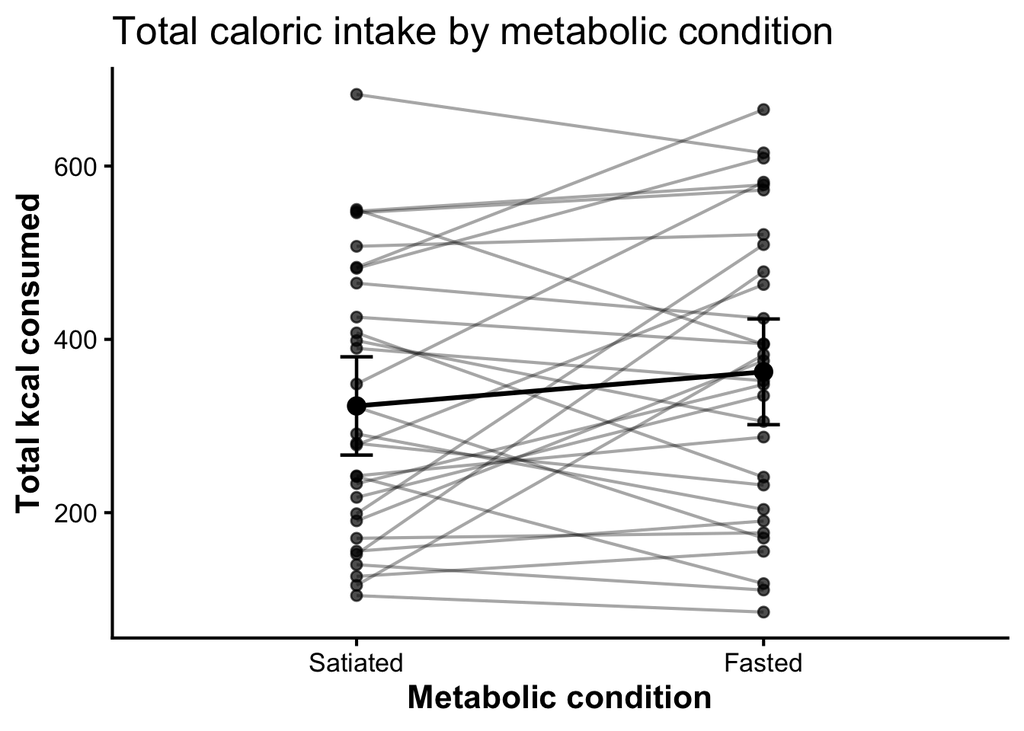

### 14.1.2 Secondary outcomes by condition

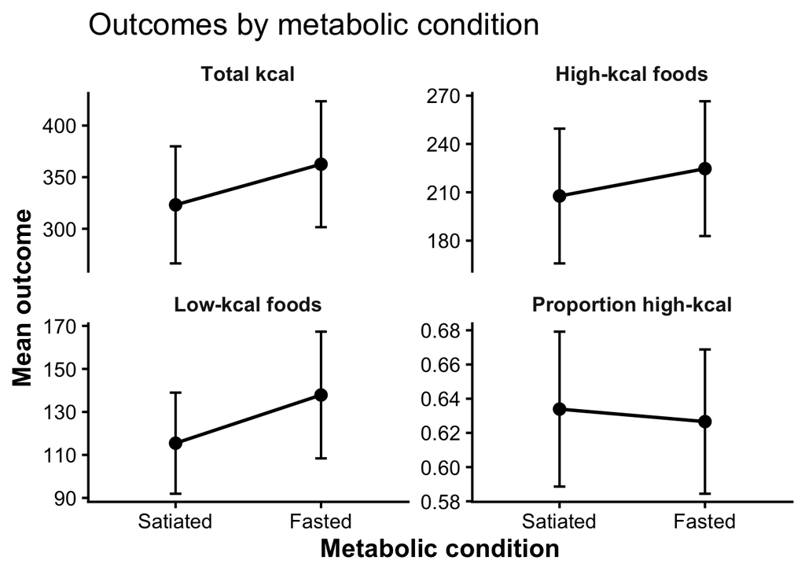

### 14.1.3 Example interaction plot for SRS

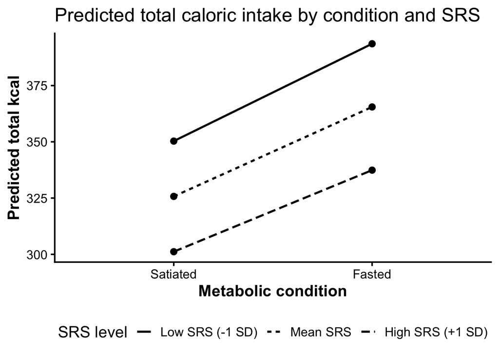

## 14.2 Diagnostics

### 14.2.1 Residual diagnostics